# Retinalogik vs HFA for COS 2026

[Eadie Technologies, Inc.](https://www.eadietech.com/)

2025-10-14

## Setup

### Versioning

Last updated on 2025-Oct-21 at 10:09 AM.

- 2025-Oct-14: Created separate .Rmd file as index.Rmd was getting very cluttered.

### Acknowledgements

Data collected by Research Assistants Luc St-Pierre, Reann Post, and Research Coordinator Lynn Murphy.

```r
# load packages
library(tidyverse)
```

```r
library(here)
## here() starts at /Users/eadie/EadieTech/retinalogik-study
library(DT)
library(plotly)
library(viridis)
library(svglite)
library(htmltools)
library(gridExtra)
library(sf)
## Linking to GEOS 3.13.0, GDAL 3.8.5, PROJ 9.5.1; sf_use_s2() is TRUE
library(spdep)
library(RColorBrewer)
library(patchwork)
library(report)
library(effectsize)
library(rempsyc)
## Suggested APA citation: Thériault, R. (2023). rempsyc: Convenience functions for psychology.
## Journal of Open Source Software, 8(87), 5466. https://doi.org/10.21105/joss.05466
library(kableExtra)
# default chunk options
knitr::opts_chunk$set(
  comment = '>', collapse = TRUE, cache = FALSE, dev= c("png")
  )

rm(list = ls())

# load processed data
load(here("dBdat_cos.Rda"))

dBdat_flipped <- dBdat %>%
  mutate(x = as.numeric(x), y = as.numeric(y)) %>%
  mutate(x = case_when(
    eye == "L" & device == "retinalogik" ~ x*-1,
    TRUE ~ as.numeric(x)
  )) %>%
  # remove blind spots
  filter(!(x == 15 & y == -3)) %>%
  filter(!(x == 15 & y == +3)) %>%
  #remove first 2 visits
  filter(visit != 1 & visit != 2) %>%
  #remove reliability indices >30%
  filter(flPerc < 30 & fnPerc < 30 & fpPerc < 30) %>%
  group_by(id, device, eye) %>%
  mutate(meanmd = mean(md))

classification <- readxl::read_excel("RetinaLogik Data Classification.xlsx") %>%
  mutate(
    # Extract the numeric part after "RL"
    numeric_part = as.numeric(str_extract(ID, "\\d+")),
    # Format the numeric part to have at least two digits with leading zeros
    formatted_numeric = str_pad(numeric_part, width = 2, side = "left", pad = "0"),
    # Combine "RL" with the formatted number
    ID = paste0("RL", formatted_numeric)
  ) %>%
  # Remove the temporary columns
  select(-numeric_part, -formatted_numeric) %>%
  rename(id = ID, classification = Classifcation, eye = `Eye (OD/OS)`) %>%
  mutate(eye = case_when(eye == "OS" ~ "L",
                         eye == "OD" ~ "R",
                         eye == "OU" ~ "R"))

dBdat_filtered <- merge(dBdat_flipped, classification) %>%
  filter(id != "RL31") %>% # patient kept ghosting Reann
  filter(classification != "Control")
```

# Study summary

We compared 24-2 visual field (VF) test results between Retinalogik and the Humphrey Field Analyzer (HFA) using SITA Standard test strategy in patients with early glaucoma and moderate to advanced glaucoma [here](https://vvnejl.github.io/retinalogik-study/). A scotoma analysis was performed following glaucomatous VF definitions found in Park et al. (2011). Scotoma analysis results may be found [here](https://vvnejl.github.io/retinalogik-study/scotoma_analysis.html).

# Methods (very briefly)

## Subjects

Eligible participants were identified among patients of Dr. Brennan Eadie at the Eadie Eye Centre. If deemed eligible for the study, subjects were recruited consecutively.

Each participant underwent five study visits. At each visit, they performed a VF test on both eyes using the two devices. The order of device tested was randomized at the first (baseline) study visit.

Exclusion criteria were:

- age <18 years
- diagnosis of secondary glaucoma
- diagnosis of non-glaucomatous optic neuropathy
- significant media opacity
- previous intraocular surgery
- pregnancy
- seizure disorder
- cardiac pacemaker or other implantable device
- severe vertigo or balance disturbance
- inability to demonstrate competence to make an informed decision regarding study participation

The study adhered to the tenets of the Declaration of Helsinki for research involving human subjects and the protocol was approved by the Nova Scotia Health Research Ethics Board (#1030608). All participants gave their written informed consent before enrollment in the study.

# Analysis

Of the 5 visits, the first 2 visits were removed from analysis. VFTs where reliability indices (FL, FP, and FN) > 30% were removed from analysis as well.

## Demographics

Demographics information for partial dataset:

```r
totaldemo <- dBdat_filtered %>%
  group_by(id, gender, classification) %>%
  summarise(age = mean(age)) %>%
  mutate(id = as.factor(id),
         gender = as.factor(gender),
         classification = as.factor(classification))
> `summarise()` has grouped output by 'id', 'gender'. You can override using the
> `.groups` argument.

summary(totaldemo) %>%
  kable()
```

|  | id | gender | classification | age |
| --- | --- | --- | --- | --- |
|  | RL01 : 1 | M:16 | Mild :14 | Min. :44.00 |
|  | RL03 : 1 | F:13 | Advanced: 9 | 1st Qu.:66.00 |
|  | RL04 : 1 | NA | Moderate: 6 | Median :72.00 |
|  | RL06 : 1 | NA | NA | Mean :69.83 |
|  | RL07 : 1 | NA | NA | 3rd Qu.:77.00 |
|  | RL10 : 1 | NA | NA | Max. :82.00 |
|  | (Other):23 | NA | NA | NA |

After matching mean sensitivity, only 23 datasets remained for paired t-test comparisons. For example, RL07’s HFA didn’t meet criteria and RL11’s RT data didn’t meet criteria. Below are the ones reported for COS abstract.

```r
ms <- dBdat_filtered %>%
  group_by(id, device) %>%
  mutate(mean = mean(dB)) %>%
  distinct(id, classification, mean, age, gender) %>%
  pivot_wider(names_from = device, values_from = mean) %>%
  mutate(classification = factor(classification, levels = c("Mild", "Moderate", "Advanced"))) %>%
  drop_na()

demo <- ms %>%
  group_by(id, gender, classification) %>%
  summarise(age = mean(age)) %>%
  mutate(id = as.factor(id),
         gender = as.factor(gender),
         classification = as.factor(classification))
> `summarise()` has grouped output by 'id', 'gender'. You can override using the
> `.groups` argument.

summary(demo) %>%
  kable()
```

|  | id | gender | classification | age |
| --- | --- | --- | --- | --- |
|  | RL01 : 1 | M:11 | Mild :12 | Min. :44.0 |
|  | RL03 : 1 | F:12 | Moderate: 5 | 1st Qu.:65.5 |
|  | RL04 : 1 | NA | Advanced: 6 | Median :70.0 |
|  | RL06 : 1 | NA | NA | Mean :69.0 |
|  | RL10 : 1 | NA | NA | 3rd Qu.:76.0 |
|  | RL12 : 1 | NA | NA | Max. :82.0 |
|  | (Other):17 | NA | NA | NA |

## Stats

### Mean sensitivity

```r
ms %>%
  group_by(classification) %>%
  summarise(
    n = n(),
    median_retinalogik = median(retinalogik, na.rm = TRUE),
    q1_retinalogik = quantile(retinalogik, .25, na.rm = TRUE),
    q3_retinalogik = quantile(retinalogik, .75, na.rm = TRUE),
    iqr_retinalogik = IQR(retinalogik, na.rm = TRUE),
    median_hfa = median(hfa, na.rm = TRUE),
    q1_hfa = quantile(hfa, .25, na.rm = TRUE),
    q3_hfa = quantile(hfa, .75, na.rm = TRUE),
    iqr_hfa = IQR(hfa, na.rm = TRUE)
  ) %>%
  nice_table()
```

| classification | n | median_retinalogik | q1_retinalogik | q3_retinalogik | iqr_retinalogik | median_hfa | q1_hfa | q3_hfa | iqr_hfa |
| --- | --- | --- | --- | --- | --- | --- | --- | --- | --- |
| Mild | 12 | 28.82 | 28.12 | 29.78 | 1.66 | 27.54 | 25.77 | 28.04 | 2.27 |
| Moderate | 5 | 25.51 | 24.91 | 25.62 | 0.70 | 20.54 | 19.13 | 22.03 | 2.90 |
| Advanced | 6 | 21.17 | 17.24 | 22.98 | 5.73 | 15.04 | 13.61 | 18.57 | 4.96 |

## Plots

“Pointwise analysis revealed that the absolute difference was greatest at peripheral loci.”

Mean threshold sensitivities (SDs in parentheses) are shown, followed by the mean differences in threshold sensitivities between the two devices and the SDs of those differences (in parentheses).

```r
nRT <- dBdat_filtered %>%
  filter(classification == "Mild" & device == "retinalogik") %>%
  distinct(id, device, visit, eye) %>%
  n_distinct()

nHFA <- dBdat_filtered %>%
  filter(classification == "Mild" & device == "hfa") %>%
  distinct(id, device, visit, eye) %>%
  n_distinct()

meanSensitivity <- dBdat_filtered %>%
  filter(classification == "Mild") %>%
  distinct(id, device, visit, eye, x, y, dB) %>%
  pivot_wider(names_from = device, values_from = dB) %>%
  mutate(diff = hfa-retinalogik) %>%
  group_by(x, y) %>%
  summarize(meanRT = mean(retinalogik, na.rm=T), sdRT = sd(retinalogik, na.rm=T),
            meanHFA = mean(hfa, na.rm=T), sdHFA = sd(hfa, na.rm=T),
            meanDiff = mean(diff, na.rm=T), sdDiff = sd(diff, na.rm=T)) %>%
  ungroup() %>%
  add_row(tibble_row(x = 15, y = -3, meanRT = NA, sdRT = NA)) %>%
  add_row(tibble_row(x = 15, y = +3, meanRT = NA, sdRT = NA))
> `summarise()` has grouped output by 'x'. You can override using the `.groups`
> argument.

rtplot_earlyGON <- meanSensitivity %>%
  ggplot(aes(x, y, meanRT)) +
  geom_raster(aes(x = x, y = y, fill = meanRT)) +
  geom_text(aes(label = ifelse(is.na(meanRT), "", paste0(round(meanRT, 2), "\n(", round(sdRT, 2), ")")),
                x = x, y = y), size = 2, colour="white") +
  coord_fixed(ratio = 1) +
  scale_fill_gradientn(colours = viridis(51), limits = c(-1, 49),
                       na.value="darkred") +
  theme_bw() +
  ggtitle("Retinalogik", subtitle = paste0("(n = ", nRT, " early GON eyes)")) +
  theme(legend.position="none")

hfaplot_earlyGON <- meanSensitivity %>%
  ggplot(aes(x, y, meanHFA)) +
  geom_raster(aes(x = x, y = y, fill = meanHFA)) +
  geom_text(aes(label = ifelse(is.na(meanHFA), "", paste0(round(meanHFA, 2), "\n(", round(sdHFA, 2), ")")),
                x = x, y = y), size = 2, colour="white") +
  coord_fixed(ratio = 1) +
  scale_fill_gradientn(colours = viridis(51), limits = c(-1, 49),
                       na.value="darkred") +
  theme_bw() +
  ggtitle("HFA", subtitle = paste0("(n = ", nHFA, " early GON eyes)")) +
  theme(legend.position="none")

diffplot_earlyGON <- meanSensitivity %>%
  ggplot(aes(x, y, meanDiff)) +
  geom_raster(aes(x = x, y = y, fill = meanDiff)) +
  geom_text(aes(label = ifelse(is.na(meanDiff), "", paste0(round(meanDiff, 2), "\n(", round(sdDiff, 2), ")")),
                  x = x, y = y), size = 3) +
  coord_fixed(ratio = 1) +
  scale_fill_gradientn(colours = rainbow(17), limits = c(-8, 8),
                       na.value="darkred") +
  theme_bw() +
  ggtitle("HFA-Retinalogik")

## Moderate GON
nRT <- dBdat_filtered %>%
  filter(classification == "Moderate" & device == "retinalogik") %>%
  distinct(id, device, visit, eye) %>%
  n_distinct()

nHFA <- dBdat_filtered %>%
  filter(classification == "Moderate" & device == "hfa") %>%
  distinct(id, device, visit, eye) %>%
  n_distinct()

meanSensitivity <- dBdat_filtered %>%
  filter(classification == "Moderate") %>%
  distinct(id, device, visit, eye, x, y, dB) %>%
  pivot_wider(names_from = device, values_from = dB) %>%
  mutate(diff = hfa-retinalogik) %>%
  group_by(x, y) %>%
  summarize(meanRT = mean(retinalogik, na.rm=T), sdRT = sd(retinalogik, na.rm=T),
            meanHFA = mean(hfa, na.rm=T), sdHFA = sd(hfa, na.rm=T),
            meanDiff = mean(diff, na.rm=T), sdDiff = sd(diff, na.rm=T)) %>%
  ungroup() %>%
  add_row(tibble_row(x = 15, y = -3, meanRT = NA, sdRT = NA)) %>%
  add_row(tibble_row(x = 15, y = +3, meanRT = NA, sdRT = NA))
> `summarise()` has grouped output by 'x'. You can override using the `.groups`
> argument.

rtplot_moderateGON <- meanSensitivity %>%
  ggplot(aes(x, y, meanRT)) +
  geom_raster(aes(x = x, y = y, fill = meanRT)) +
  geom_text(aes(label = ifelse(is.na(meanRT), "", paste0(round(meanRT, 2), "\n(", round(sdRT, 2), ")")),
                x = x, y = y), size = 2, colour="white") +
  coord_fixed(ratio = 1) +
  scale_fill_gradientn(colours = viridis(51), limits = c(-1, 49),
                       na.value="darkred") +
  theme_bw() +
  ggtitle("Retinalogik", subtitle = paste0("(n = ", nRT, " moderate GON eyes)")) +
  theme(legend.position="none")

hfaplot_moderateGON <- meanSensitivity %>%
  ggplot(aes(x, y, meanHFA)) +
  geom_raster(aes(x = x, y = y, fill = meanHFA)) +
  geom_text(aes(label = ifelse(is.na(meanHFA), "", paste0(round(meanHFA, 2), "\n(", round(sdHFA, 2), ")")),
                x = x, y = y), size = 2, colour="white") +
  coord_fixed(ratio = 1) +
  scale_fill_gradientn(colours = viridis(51), limits = c(-1, 49),
                       na.value="darkred") +
  theme_bw() +
  ggtitle("HFA", subtitle = paste0("(n = ", nHFA, " moderate GON eyes)")) +
  theme(legend.position="none")

diffplot_moderateGON <- meanSensitivity %>%
  ggplot(aes(x, y, meanDiff)) +
  geom_raster(aes(x = x, y = y, fill = meanDiff)) +
  geom_text(aes(label = ifelse(is.na(meanDiff), "", paste0(round(meanDiff, 2), "\n(", round(sdDiff, 2), ")")),
                  x = x, y = y), size = 3) +
  coord_fixed(ratio = 1) +
  scale_fill_gradientn(colours = rainbow(17), limits = c(-8, 8),
                       na.value="darkred") +
  theme_bw() +
  ggtitle("HFA-Retinalogik")

## Advanced GON
nRT <- dBdat_filtered %>%
  filter(classification == "Advanced" & device == "retinalogik") %>%
  distinct(id, device, visit, eye) %>%
  n_distinct()

nHFA <- dBdat_filtered %>%
  filter(classification == "Advanced" & device == "hfa") %>%
  distinct(id, device, visit, eye) %>%
  n_distinct()

meanSensitivity <- dBdat_filtered %>%
  filter(classification == "Advanced") %>%
  distinct(id, device, visit, eye, x, y, dB) %>%
  pivot_wider(names_from = device, values_from = dB) %>%
  mutate(diff = hfa-retinalogik) %>%
  group_by(x, y) %>%
  summarize(meanRT = mean(retinalogik, na.rm=T), sdRT = sd(retinalogik, na.rm=T),
            meanHFA = mean(hfa, na.rm=T), sdHFA = sd(hfa, na.rm=T),
            meanDiff = mean(diff, na.rm=T), sdDiff = sd(diff, na.rm=T)) %>%
  ungroup() %>%
  add_row(tibble_row(x = 15, y = -3, meanRT = NA, sdRT = NA)) %>%
  add_row(tibble_row(x = 15, y = +3, meanRT = NA, sdRT = NA))
> `summarise()` has grouped output by 'x'. You can override using the `.groups`
> argument.

rtplot_advancedGON <- meanSensitivity %>%
  ggplot(aes(x, y, meanRT)) +
  geom_raster(aes(x = x, y = y, fill = meanRT)) +
  geom_text(aes(label = ifelse(is.na(meanRT), "", paste0(round(meanRT, 2), "\n(", round(sdRT, 2), ")")),
                x = x, y = y), size = 2, colour="white") +
  coord_fixed(ratio = 1) +
  scale_fill_gradientn(colours = viridis(51), limits = c(-1, 49),
                       na.value="darkred") +
  theme_bw() +
  ggtitle("Retinalogik", subtitle = paste0("(n = ", nRT, " advanced GON eyes)")) +
  theme(legend.position="none")

hfaplot_advancedGON <- meanSensitivity %>%
  ggplot(aes(x, y, meanHFA)) +
  geom_raster(aes(x = x, y = y, fill = meanHFA)) +
  geom_text(aes(label = ifelse(is.na(meanHFA), "", paste0(round(meanHFA, 2), "\n(", round(sdHFA, 2), ")")),
                x = x, y = y), size = 2, colour="white") +
  coord_fixed(ratio = 1) +
  scale_fill_gradientn(colours = viridis(51), limits = c(-1, 49),
                       na.value="darkred") +
  theme_bw() +
  ggtitle("HFA", subtitle = paste0("(n = ", nHFA, " advanced GON eyes)")) +
  theme(legend.position="none")

diffplot_advancedGON <- meanSensitivity %>%
  ggplot(aes(x, y, meanDiff)) +
  geom_raster(aes(x = x, y = y, fill = meanDiff)) +
  geom_text(aes(label = ifelse(is.na(meanDiff), "", paste0(round(meanDiff, 2), "\n(", round(sdDiff, 2), ")")),
                  x = x, y = y), size = 3) +
  coord_fixed(ratio = 1) +
  scale_fill_gradientn(colours = rainbow(17), limits = c(-8, 8),
                       na.value="darkred") +
  theme_bw() +
  ggtitle("HFA-Retinalogik")
```

### Mild GON

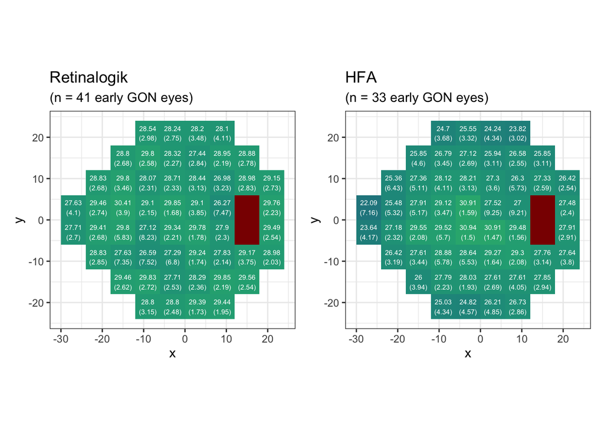

```r
rtplot_earlyGON + hfaplot_earlyGON
```

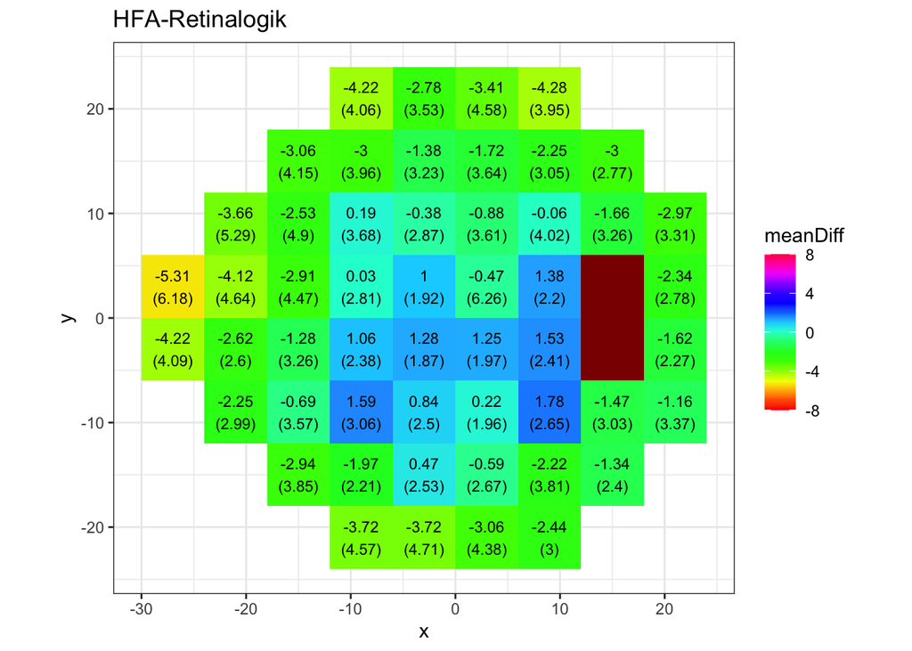

```r
diffplot_earlyGON
```

### Moderate GON

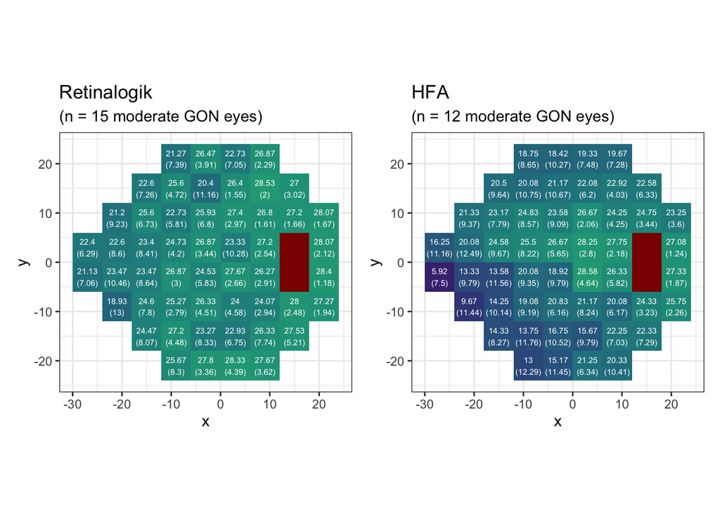

```r
rtplot_moderateGON + hfaplot_moderateGON
```

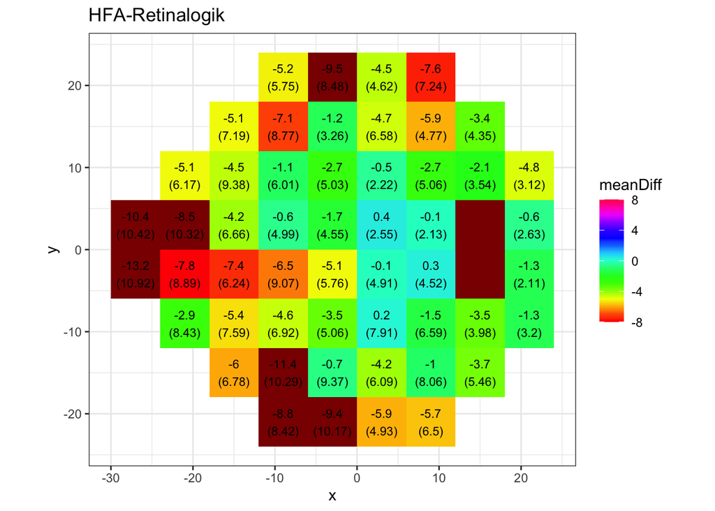

```r
diffplot_moderateGON
```

### Advanced GON

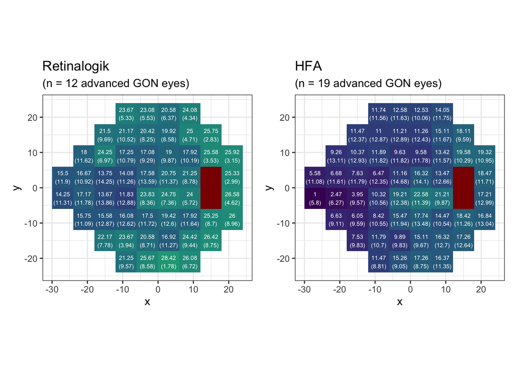

```r
rtplot_advancedGON + hfaplot_advancedGON
```

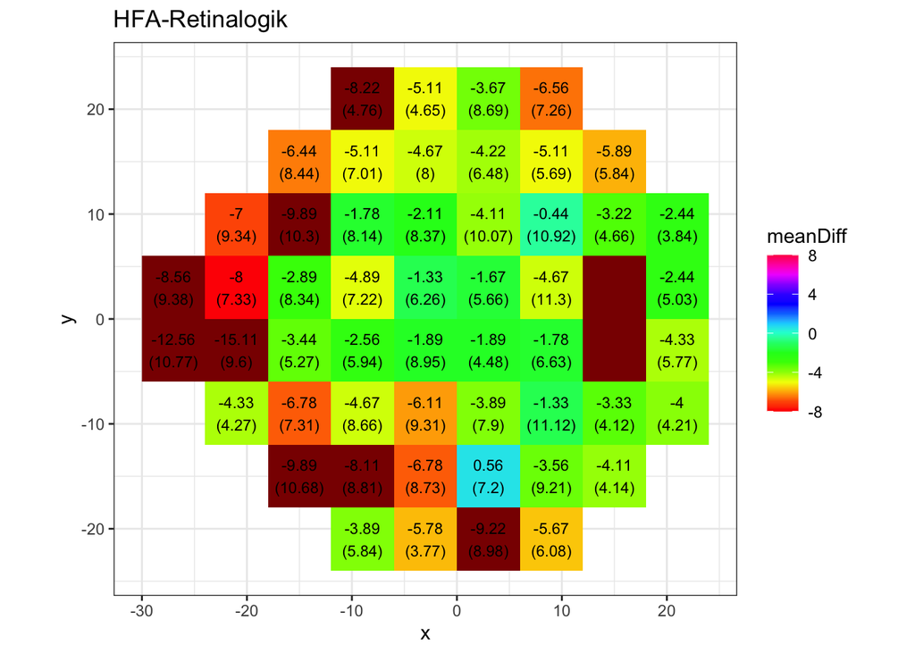

```r
diffplot_advancedGON
```

Report by [Vivian Eng](https://ca.linkedin.com/in/vivianjleng)

*vivian@eadietech.com*